```python
%%javascript
IPython.OutputArea.prototype._should_scroll = function(lines) {
    return false;
}
```

```python
# Center matplotlib images
from IPython.core.display import HTML
HTML("""
<style>
.output_png {
    display: table-cell;
    text-align: center;
    vertical-align: middle;
}
</style>
""")
```

# Post Goals:

1. Provide a short introduction to set theory
2. Provide an introduction to Venn Diagrams using Python.
3. Demonstrate how to use python to calculate three laws of probability.

# Post Overview.

1. Introduction to Set Theory.
2. Set Operations.
3. Introduction to Venn Diagrams.
4. Use Venn Diagrams to discuss the law of Total Probability.
5. Use Venn Diagrams to discuss the additive law.
6. Use Venn Diagrams to discuss the complement rule.

# Introduction to Set Theory.

**The Basics**

- Set theory is a branch of mathematical logic that studies collections of objects (formally called **sets**.
- A **Set** is an unordered collection of non-repeating objects.
- Objects in sets are also referred to as *elements* or *members*.
- Georg Cantor is regarded as the father of modern set theory, and this branch of mathematics was founded by his 1874 paper ["On a property of the collection of All Real Algebraic Numbers".](https://en.wikipedia.org/wiki/Cantor%27s_first_set_theory_article)
- Venn diagrams are used to illustrate basic concepts and binary operations on sets.

**Applications**

- Set theory is used to define graphs, manifolds, rings and vector spaces.
- Set theory can be used to derive properties of natural and real numbers.
- Set theory serves as a foundation for mathematical analysis, abstract algebra, probability, and discrete mathematics.

**Describing a set**

- A set is described by listing all the elements inside a curly bracket or described using a written description inside curly brackets.
- \(S = \{1,3,5,7,9\} \).
- S is the set whose elements are 1,3,5,7,9.
- General form is \[A = \{x : property\} \].

**Set Notation**

- \(\varnothing \) **Empty Set**
- \(\mathbb{N} \) **Set of Natural Numbers**
- \(\mathbb{Z} \) **Set of Integers**
- \(\mathbb{Q} \) **Set of Rational Numbers**
- \(\mathbb{A} \) **Set of Algebraic Numbers**
- \(\mathbb{R} \) **Set of Real Numbers**
- \(\mathbb{C} \) **Set of Complex Numbers**
- \(\in \) **is member of**
- \(\notin \) **is not a member of**
- \(\ni \) **owns (has member)**
- \(\subset \) **is proper subset of**
- \(\subseteq \) **is subset of**
- \(\supset \) **is proper superset of**
- \(\cup \) **set union**
- \(\cap \) **set intersection**

**Types of Sets**

- **Empty Set** does not contain any elements, and is denoted as \(\varnothing \) or {}
- **Singleton Set** contains a single element.
- **Finite Set** contains a definite number of elements.
- **Infinite Set** is not finite, such as a set of all natural numbers \(\mathbb{N} \).
- **Equivalent Set** describes a situation when the number of elements is the same for two different sets. The order of sets does not matter. \(n(A) = n(B) \) where A and b are two different sets
- **Equal Set** the two sets A and b are equal if they have the exact same elements. \(S_{A} = \{1,2,3,4\} \) = \(S_{B} = \{1,2,3,4\} \), thus \(S_{A} = S_{B} \)
- **Disjoint Set** Condition in which two sets that are compared do not contain any common elements.  
  \(S_{A} = \{1,2,3,4\} \) = \(S_{B} = \{5,6,7,8\} \), thus \(S_{A} \neq S_{B} \)
- **Subset** A set is a subset if every element is also an element in another set.  
  \(S_{A} = \{1,2,3,4\} \) = \(S_{B} = \{1,2,3,4,5,6,7,8\} \), thus \(S_{A} \subseteq S_{B} \)  
  a set is also a subset of itself. if a set is not a subset of another set, such as \(S_{C} = \{1,2\} \) = \(S_{D} = \{6,7,8\} \), , then it would described as \(S_{C} \nsubseteq S_{D} \)
- **Proper Subset** is a set that meets two conditions: 1) all the elements are contained in a larger set \(S_{A} = \{1,2\} \in S_{B} = \{1,2,3,4\} \) and 2) the proper subset is not an equal set to the larger set \(S_{A} \{1,2\} \neq S_{B} \{1,2,3,4\} \)
- **Super Set** A set is a superset of another set if all elements in one set are represented in the superset.  
  \(S_{A} = \{A,B,C,D\} \supset S_{B} = \{A,C\} \)
- **Universal Set** is a set that contains all the sets relevant to a certain condition.  
  \(S_{Universal} = \{A,B,C,D\}, S_{A} = \{A,C\}, S_{B} = \{B,D\} \)

# Set Operations and Formulas.

**Common Operations**

- **Union of Sets**: Is the set that contains all the elements of two sets and is denoted using the \(\cup\) symbol, example: \(A \cup B\)
- **Intersection of Sets**: Is the set that contains only common elements between sets and is denoted using the \(\cap\) symbol, example: \(A \cap B\)
- **Complement of Sets**: Is the set of all elements in the universal set that are not in a specific set and is denoted using an apostrophy example: Set \(P'\) has elements that are not in \(P\)
- **Difference of Sets**: if set A and set B are two sets, then the difference of sets for A as denoted as \(A - B\) is the set that contains elements in A but not in B.

**Common Set Formulas with Probability**

# Introduction to Venn Diagrams.

**The Basics**

**Create Venn Diagrams using Python**

- **Dependencies include**
  - `matplotlib`: library used for creating static, animated and interactive visualizations using python.
  - `matplotlib_venn`: library used to plot area-proportional two and three-way Venn diagrams in matplotlib. Developed by [konstantint](https://github.com/konstantint/matplotlib-venn)
  - `venn2, venn2_circles, venn2_unweighted`: are main functions that accept 3-element list of subset sizes and draws a two-circle venn diagram with respective region areas. `venn2_unweighted` draw the Venn diagram without area-weighting.
  - `venn3, venn3_circles`: are main functions that accept 3-element list of subset sizes and draws a three-circle venn diagram with respective region areas. `venn2_unweighted` draw the Venn diagram without area-weighting.
- `plt.axis("on")`: adds a border around venn diagram figure
- `plt.text(-0.62, 0.5, s=6)`: adds the number of instances outside of the diagrammed sets

```python
#Import libraries
from matplotlib_venn import venn2, venn2_circles, venn2_unweighted
from matplotlib_venn import venn3, venn3_circles
from matplotlib import pyplot as plt
%matplotlib inline
```

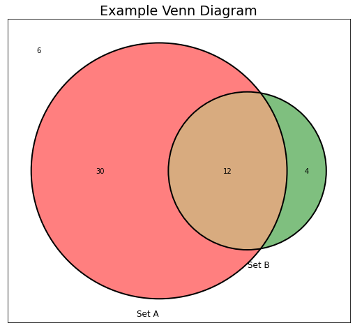

```python
fig = plt.figure(frameon=True)
subsets = (30, 4, 12)

# plot the venn diagrams
venn2(subsets = subsets, set_labels = ('Set A', 'Set B'),
     set_colors=('r', 'g'), alpha = 0.5)

# add text for instances that are not in Set a or Set b
plt.text(-0.62, 0.5, s=6)

# format venn diagram
venn2_circles(subsets = subsets)
plt.rcParams.update({'font.size': 16})

# format image size
fig.set_figheight(8)
fig.set_figwidth(10)

plt.axis("on") # add box
plt.title("Example Venn Diagram")
plt.show()
```

# Use Venn Diagrams to Illustrate the Law of Total Probability.

**The basics**

- The total law of probability is a fundamental rule that expresses the total probability of an outcome.
- The theorem states that in a discrete case, if \[\{B_{n}: n = 1, 2, 3...\} \]  
  is a finite of a sample space, and each event in \(B_{n}\) is measurable, than for an event \(A\), of the same probability space:  
  \[P(A) = \Sigma_{n}P(A\cap B_{n}) \]
- This expression can also be written as: \[P(A) = \Sigma_{n}P(A | B_{n})P(B_{n}) \]  
  where, for any \(n\) for which \(P(B_{n}) = 0\) these terms are omitted from the summation, between \(P(A|B_{n}) \) is finite
- The law of probability can also be stated for conditional probabilities as:  
  \[P(A|C) = \Sigma_{n}P(A | C\cap B_{n})P(B_{n} |C) \]  
  taking the \(B_{n}\) as above and assuming C is an event independent of any of the \(B_{n}\)  
  \[P(A|C) = \Sigma_{n}P(A | C\cap B_{n})P(B_{n}) \]
- Finally, this expression can also be written as: \[P(B) = P(A \cap B) + P(A' \cap B)\]
- In the example below:  
  \[P(A \cap B) = 12/52\]  
  \[P(A'\cap B) = 4/52\]  
  \[P(B) = 12/52 + 4/52 = 16/52 = 0.31\]

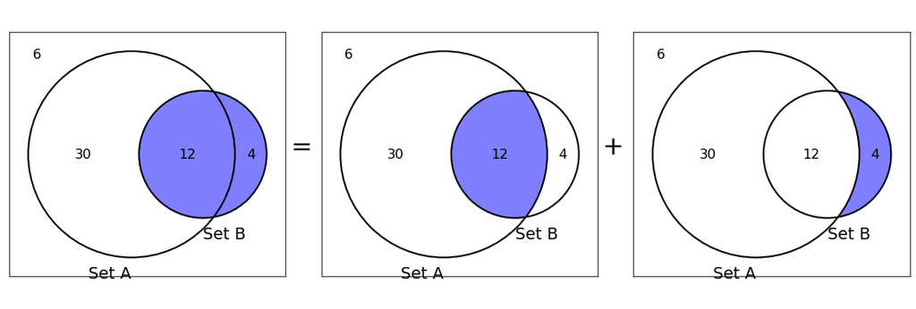

```python
fig, (ax1, ax2, ax3, ax4, ax5) = plt.subplots(1, 5, figsize=(15,5), gridspec_kw={'width_ratios': [1, 0.05, 1, 0.05, 1]}, constrained_layout=True)

v1 = venn2(subsets = subsets, set_labels = ('Set A', 'Set B'), set_colors=('w', 'b'), alpha = 0.5, ax=ax1)
# print(v1.id2idx)
v1.get_patch_by_id("11").set_color('blue') # changes color for intersection
venn2_circles(subsets = subsets, ax=ax1) # add border
ax1.axis("on") # add box
# add text for instances that are not in Set a or Set b
ax1.text(-0.62, 0.5, s=6)

ax2.text(-0.62, 0.5, s="=",fontsize=30.)
ax2.axis("off") # add box

v2 = venn2(subsets = subsets, set_labels = ('Set A', 'Set B'), set_colors=('w', 'b'), alpha = 0.5, ax=ax3)
v2.get_patch_by_id("11").set_color('blue')
v2.get_patch_by_id("010").set_color('white')
venn2_circles(subsets = subsets, ax=ax3)
ax3.axis("on") # add box
# add text for instances that are not in Set a or Set b
ax3.text(-0.62, 0.5, s=6)

ax4.text(-0.62, 0.5, s="+",fontsize=30.)
ax4.axis("off") # add box

v3 = venn2(subsets = subsets, set_labels = ('Set A', 'Set B'), set_colors=('w', 'b'), alpha = 0.5, ax=ax5)
v3.get_patch_by_id("11").set_color('white')
v3.get_patch_by_id("010").set_color('blue')
venn2_circles(subsets = subsets, ax=ax5)
ax5.axis("on") # add box
# add text for instances that are not in Set a or Set b
ax5.text(-0.62, 0.5, s=6)

plt.rcParams.update({'font.size': 16})
plt.show()
```

# Use Venn Diagrams to discuss the additive law.

**The Basics**

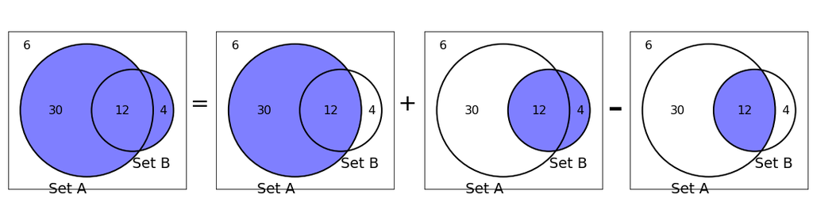

```python
# print(v1.id2idx)
fig, (ax1, ax2, ax3, ax4, ax5, ax6, ax7) = plt.subplots(1, 7, figsize=(15,4), gridspec_kw={'width_ratios': [1, 0.05, 1, 0.05, 1, 0.05, 1]}, constrained_layout=True)

# Venn diagram 1
v1 = venn2(subsets = subsets, set_labels = ('Set A', 'Set B'), set_colors=('b', 'b'), alpha = 0.5, ax=ax1)
venn2_circles(subsets = subsets, ax=ax1) # add border
ax1.axis("on")
ax1.text(-0.62, 0.5, s=6)

# equal sign
ax2.text(-0.62, 0.5, s="=",fontsize=30.)
ax2.axis("off") # add box

# venn diagram 2
v2 = venn2(subsets = subsets, set_labels = ('Set A', 'Set B'), set_colors=('b', 'b'), alpha = 0.5, ax=ax3)
v2.get_patch_by_id("11").set_color('blue')
v2.get_patch_by_id("010").set_color('white')
venn2_circles(subsets = subsets, ax=ax3)
ax3.axis("on")
ax3.text(-0.62, 0.5, s=6)

# Plus sign
ax4.text(-0.62, 0.5, s="+",fontsize=30.)
ax4.axis("off") # add box

# Venn diagram 3
v3 = venn2(subsets = subsets, set_labels = ('Set A', 'Set B'), set_colors=('w', 'b'), alpha = 0.5, ax=ax5)
v3.get_patch_by_id("11").set_color('blue')
v3.get_patch_by_id("010").set_color('blue')
venn2_circles(subsets = subsets, ax=ax5)
ax5.axis("on")
ax5.text(-0.62, 0.5, s=6)

# Minus sign
ax6.text(-0.62, 0.45, s="-",fontsize=60.)
ax6.axis("off")

# Venn diagram 4
v4 = venn2(subsets = subsets, set_labels = ('Set A', 'Set B'), set_colors=('w', 'b'), alpha = 0.5, ax=ax7)
v4.get_patch_by_id("11").set_color('blue')
v4.get_patch_by_id("010").set_color('white')
venn2_circles(subsets = subsets, ax=ax7)
ax7.axis("on")
ax7.text(-0.62, 0.5, s=6)

plt.rcParams.update({'font.size': 16})
plt.show()
```

# Use Venn Diagrams to Complement Rule.

**The Basics**

- States that the sum of the probabilities of an event and its complement must be equal to 1 and is expressed as \[P(A) + P(A') = 1 \].
- It is sometimes easier to calculate the probability of the complement of an event than it is to calculate the probability of the event itself, and this is done by rewriting the expression as \[P(A') = 1 - P(A) \]
- In the example below:  
  \[P(A) = 42/52\]  
  \[4252 + P(A') = 1\]  
  \[P(A') = 1 - 42/52\]  
  \[P(A') = 0.19\]

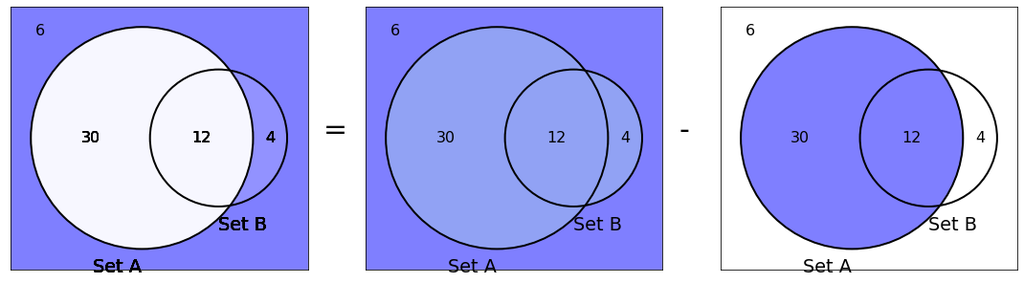

```python
fig, (ax1, ax2, ax3, ax4, ax5) = plt.subplots(1, 5, figsize=(15,4), gridspec_kw={'width_ratios': [1, 0.05, 1, 0.05, 1]}, constrained_layout=True)

# Venn diagram 1
ax1.set_facecolor('blue')
ax1.patch.set_alpha(0.5)
v1 = venn2(subsets = subsets, set_labels = ('Set A', 'Set B'), set_colors=('white', 'white'), ax=ax1)
v1 = venn2(subsets = subsets, set_labels = ('Set A', 'Set B'), set_colors=('white', 'white'), ax=ax1)
v1 = venn2(subsets = subsets, set_labels = ('Set A', 'Set B'), set_colors=('white', 'white'), ax=ax1)
v1 = venn2(subsets = subsets, set_labels = ('Set A', 'Set B'), set_colors=('white', 'white'), ax=ax1)
v1 = venn2(subsets = subsets, set_labels = ('Set A', 'Set B'), set_colors=('white', 'white'), ax=ax1)
v1 = venn2(subsets = subsets, set_labels = ('Set A', 'Set B'), set_colors=('white', 'white'), ax=ax1)
v1.get_patch_by_id("01").set_color('blue')

venn2_circles(subsets = subsets, ax=ax1) # add border
ax1.axis("on")
ax1.text(-0.62, 0.5, s=6)

# equal sign
ax2.text(-0.62, 0.5, s="=",fontsize=30.)
ax2.axis("off") # add box

# venn diagram 2
v2 = venn2(subsets = subsets, set_labels = ('Set A', 'Set B'), set_colors=('b', 'b'), ax=ax3)
v2.get_patch_by_id("100").set_color('lightblue')
v2.get_patch_by_id("11").set_color('lightblue')
v2.get_patch_by_id("010").set_color('lightblue')
venn2_circles(subsets = subsets, ax=ax3)
ax3.axis("on")
ax3.set_facecolor('b')
ax3.patch.set_alpha(0.5)
ax3.text(-0.62, 0.5, s=6)

# minus sign
ax4.text(-0.62, 0.5, s="-",fontsize=30.)
ax4.axis("off") # add box

# Venn diagram 3
v3 = venn2(subsets = subsets, set_labels = ('Set A', 'Set B'), set_colors=('b', 'w'), alpha = 0.5, ax=ax5)
v3.get_patch_by_id("11").set_color('blue')
v3.get_patch_by_id("010").set_color('white')
v3.get_patch_by_id("01").set_color('white')
venn2_circles(subsets = subsets, ax=ax5)
ax5.axis("on")
ax5.text(-0.62, 0.5, s=6)

plt.rcParams.update({'font.size': 16})
plt.show()
```